# Outlier detection (Spam dataset)

# loading and preparing SpamBase dataset

```python
import pandas as pd
import numpy as np

# Load dataset
url = "http://www.sc.ehu.es/ccwbayes/master/selected-dbs/nlp-naturallanguageprocessing/spambase.csv"
df = pd.read_csv(url)
```

**Note:** The dataset is already preprocessed, with class labels encoded as `1` (Spam) and `0` (Ham). We can now proceed directly to visualising the distribution of these classes.

### Visualising the Distribution of Spam vs Ham in the Dataset

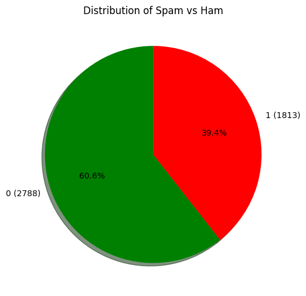

```python
import matplotlib.pyplot as plt

# Extracts the 'class' column from the DataFrame
labels = df['class']

# Counts the occurrences of each class
class_distribution = labels.value_counts()

# Plots the distribution as a pie chart
plt.figure(figsize=(6, 6))
plt.pie(
    class_distribution,
    labels=[
        f"{class_distribution.index[0]} ({class_distribution[0]})",
        f"{class_distribution.index[1]} ({class_distribution[1]})"
    ],
    autopct='%1.1f%%',
    colors=['green', 'red'],
    startangle=90,
    shadow=True
)

# Adds a title and display the plot
plt.title('Distribution of Spam vs Ham')
plt.show()
```

# Filter Non-Spam emails

```python
# Filter only non-spam emails (class = 0)
non_spam = df[df['class'] == 0]

# Drop the 'class' column (since we're focusing on outlier detection within non-spam emails)
non_spam_features = non_spam.drop(columns=['class'])
```

# Methodology: Unsupervised Outlier Detection

## 1. Why drop the 'class' column?

We remove the labels so the algorithm cannot "cheat". By relying strictly on features like word frequencies and capitalisation, we force the model to identify "weird" emails based on actual behaviour.

Since we have filtered for Ham, the `class` column would be a constant zero, offering no useful information for the algorithm to "split" on.

## 2. Why test when we already have the answers?

Using a labelled dataset allows for validation. In a real-world scenario, labels do not exist; we are testing the algorithm here to:

- **Check Accuracy**: Verify if the outliers found actually resemble Spam.
- **Fine-tune Thresholds**: Determine what a "normal" anomaly score looks like for this specific data.
- **Identify Human Error**: Spot cases where a Spam email was wrongly labelled as Ham by a person.

## 3. How Isolation Forest "sees" the data

The algorithm uses **Random Splitting logic**. Instead of defining "normal", it tries to separate each point from the rest by picking a random feature (e.g., `word_freq_remove`) and a random split value.

### Key Concepts:

- **Anomalies are "Loners"**: Outliers have extreme or rare values, so they get separated into their own "box" very quickly. For example, an email with 50 exclamation marks will likely be isolated in just one or two splits.
- **Normal points are "Crowds"**: Normal emails look very similar. You must ask many more "questions" (create more splits) to finally isolate one normal point from its neighbours.

Isolation Forest is unique because it only measures how easy it is to isolate a point:

- **Short path** (few splits) = **Outlier**
- **Long path** (many splits) = **Normal**

By averaging these "path lengths" across hundreds of random trees, the model becomes highly reliable at spotting truly unusual cases.

```python
from sklearn.ensemble import IsolationForest

# 1. Initialise the model
# 'contamination=0.05' assumes roughly 5% of Ham emails might be outliers
iso_forest = IsolationForest(contamination=0.05, random_state=42)

# 2. Fit the model using only the features (word frequencies, etc.)
iso_forest.fit(non_spam_features)

# 3. Get the Anomaly Scores
# I used -decision_function because scikit-learn returns negative values for outliers by default
# Converting it makes higher scores = more anomalous
non_spam_scores = -iso_forest.decision_function(non_spam_features)

# 4. Predict (-1 for outliers, 1 for normal)
non_spam_predictions = iso_forest.predict(non_spam_features)





print("Isolation Forest processing complete.")
```

```
Isolation Forest processing complete.
```

# Visualising the Results

To see if the algorithm actually found anything interesting we then plot the distribution of these scores.

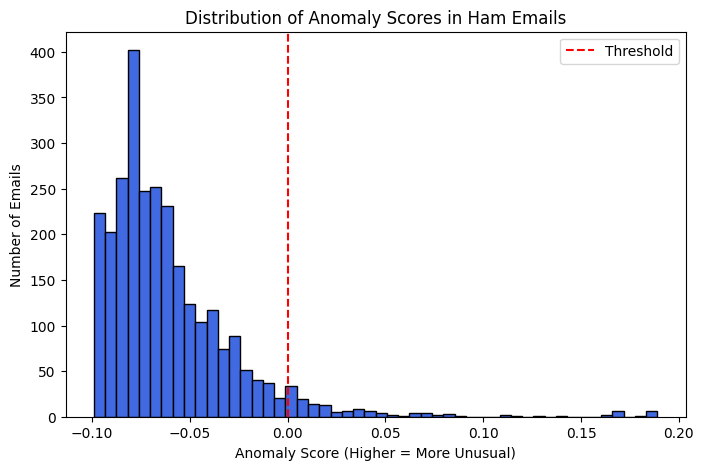

```python
plt.figure(figsize=(8, 5))
plt.hist(non_spam_scores, bins=50, color='royalblue', edgecolor='black')
plt.axvline(x=0, color='red', linestyle='--', label='Threshold')
plt.title('Distribution of Anomaly Scores in Ham Emails')
plt.xlabel('Anomaly Score (Higher = More Unusual)')
plt.ylabel('Number of Emails')
plt.legend()
plt.show()
```

# Analysis

The histogram shows that the majority of our Ham emails are "normal," clustering on the left with low anomaly scores. However, the data points to the right of the red threshold are our outliers. These specific emails were isolated very quickly by the algorithm because their features such as the frequency of "$" or "!" characters and the length of capital letter sequences are different from the rest of the Ham group.

# Conclusion

The Isolation Forest successfully flagged the most unusual emails without needing any prior labels. This demonstrates that:

- Detection works: The model can identify "weird" emails based purely on their content and behaviour.
- Validation is key: We can now manually inspect these high-scoring outliers to see if they are actually mislabelled Spam or just very unique legitimate messages.
- Real-world use: This method is highly effective for finding hidden anomalies in large, unlabelled datasets where human review is impossible.

# Local Outlier Factor (LOF)

Unlike Isolation Forest, which uses splits to isolate points, LOF looks at density. It compares how "crowded" an email's neighbourhood is compared to its neighbours. If a point is in a much sparser area than its neighbours, it’s flagged as an outlier.

```python
from sklearn.neighbors import LocalOutlierFactor

# 1. Initialise the model
# n_neighbors=20 is a standard starting point
lof = LocalOutlierFactor(n_neighbors=20, contamination=0.05)

# 2. Fit and Predict
# Note: fit_predict is used for LOF in 'novelty=False' mode
non_spam['lof_prediction'] = lof.fit_predict(non_spam_features)
non_spam['lof_score'] = -lof.negative_outlier_factor_  # Higher = more anomalous

# 3. Count the results
# -1 indicates an outlier in scikit-learn
num_lof_outliers = (non_spam['lof_prediction'] == -1).sum()
total_points = len(non_spam)

print("LOF processing complete.")
print(f"Number of outliers (LOF): {num_lof_outliers}")
print(f"Total points: {total_points}")
```

```
LOF processing complete.
Number of outliers (LOF): 140
Total points: 2788
```

# Visualising the Local Outlier Factor (LOF)

- Small Circles: Represent "normal" Ham emails in high-density regions.
- Large Circles: Represent anomalies that have a much lower local density than their neighbours.

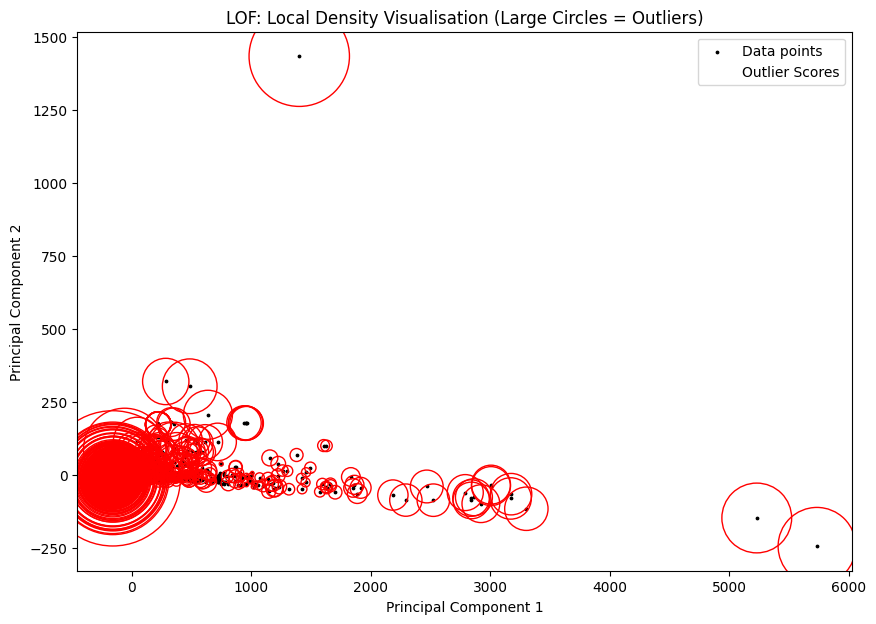

```python
from sklearn.decomposition import PCA
import matplotlib.pyplot as plt

# 1. Reduces features to 2D for plotting
pca = PCA(n_components=2)
features_2d = pca.fit_transform(non_spam_features)

# 2. Defines circle sizes based on the LOF score
# We subtract 1 and scale it so normal points (score ~1) have tiny circles
radius = (non_spam['lof_score'] - 1) * 10

plt.figure(figsize=(10, 7))
plt.scatter(features_2d[:, 0], features_2d[:, 1], color='k', s=3, label='Data points')

# Plots circles around the points; larger circles = higher outlier score
plt.scatter(features_2d[:, 0], features_2d[:, 1], s=radius * 100,
            edgecolors='r', facecolors='none', label='Outlier Scores')

plt.title('LOF: Local Density Visualisation (Large Circles = Outliers)')
plt.xlabel('Principal Component 1')
plt.ylabel('Principal Component 2')
plt.legend()
plt.show()
```

# Analysis

The visualisation reveals three distinct data patterns:

- Normal Culster: Dense concentration on the far left represents the majority of emails with similar feature distributions, forming high-density regions.
- Global Outliers: Large circles at the extremes (far right and top) indicate emails with anomalous feature values (e.g., excessive capitalization) that are isolated from all other data points.
- Local Outliers: Medium-sized circles between the normal cluster and extremes represent emails that deviate significantly from their local neighbourhoods but are less extreme than global outliers. Conclusion

The LOF algorithm successfully identified anomalous patterns in the dataset:

- Detection Method: The algorithm identifies isolation within - - feature space rather than simply flagging extreme values, enabling detection of contextually anomalous data points.
- Findings: While most Ham emails exhibit predictable characteristics, a subset displays irregular patterns warranting further investigation for potential mislabeling.

# What is an Autoencoder?

An Autoencoder is a neural network designed to learn a "compressed" representation of your data. It consists of two parts:

- The Encoder: Compresses the input (email features) into a small, dense "bottleneck" layer.
- The Decoder: Tries to reconstruct the original input from that compressed version.

Why it works for Outlier Detection

- Normal Emails: Since 95% of the data is "normal" Ham, the network becomes very good at compressing and reconstructing typical email patterns.
- Outliers: When the network sees a "weird" email (an outlier), it doesn't know how to handle it properly. It will do a poor job of reconstructing it.
- Reconstruction Error: We measure the difference between the Input and the Output. A high error means the email is an outlier.

```python
from sklearn.neural_network import MLPRegressor
from sklearn.preprocessing import StandardScaler

# 1. Scaling up for the Neural Network
scaler = StandardScaler()
scaled_features = scaler.fit_transform(non_spam_features)

# 2. Initialise the Autoencoder
# We use a single hidden layer of 10 neurons (the 'bottleneck')
autoencoder = MLPRegressor(hidden_layer_sizes=(10,),
                           activation='relu',
                           solver='adam',
                           random_state=42,
                           max_iter=500)

# 3. Fit the model
#map 'scaled_features' to 'scaled_features' (Input = Output)
autoencoder.fit(scaled_features, scaled_features)

# 4. Calculate Reconstruction Error (Mean Squared Error)
reconstruction = autoencoder.predict(scaled_features)
mse = ((scaled_features - reconstruction) ** 2).mean(axis=1)

non_spam['ae_score'] = mse

# 5. Identify the top 140 outliers to stay consistent with other outlier models
threshold = np.percentile(mse, 95)
non_spam['ae_prediction'] = np.where(non_spam['ae_score'] >= threshold, -1, 1)

print("Autoencoder processing complete.")
print(f"Detected {(non_spam['ae_prediction'] == -1).sum()} outliers based on highest reconstruction error.")
```

```
Autoencoder processing complete.
Detected 140 outliers based on highest reconstruction error.
```

# Histogram of Reconstruction Errors

This graph shows the distribution of "mistakes" the model made.

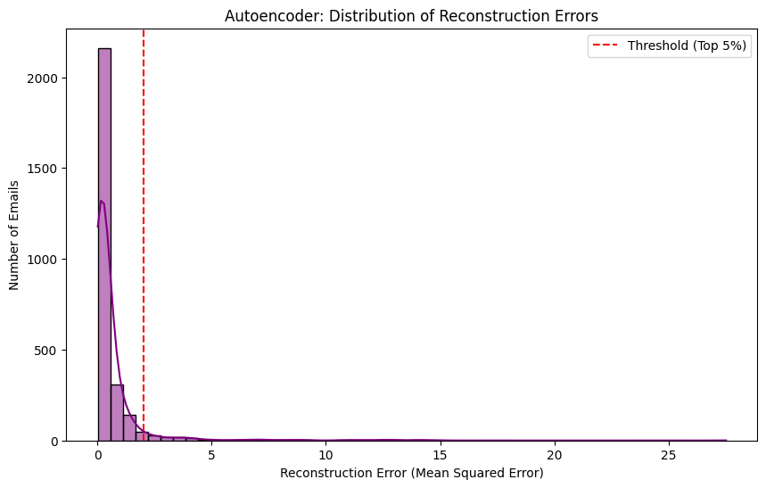

```python
import matplotlib.pyplot as plt
import seaborn as sns
import numpy as np

# 1. Defines the threshold for the top 5%
threshold = np.percentile(non_spam['ae_score'], 95)

# 2. Plots the distribution
plt.figure(figsize=(10, 6))
sns.histplot(non_spam['ae_score'], bins=50, kde=True, color='purple')

# Adds a vertical line for the threshold
plt.axvline(threshold, color='r', linestyle='--', label=f'Threshold (Top 5%)')

plt.title('Autoencoder: Distribution of Reconstruction Errors')
plt.xlabel('Reconstruction Error (Mean Squared Error)')
plt.ylabel('Number of Emails')
plt.legend()
plt.show()
```

# Reconstruction Error Distribution (Histogram)

This shows how well the model reconstructed each email:

- The tall peak near 0: Most emails were reconstructed almost perfectly, meaning the Autoencoder learned the typical structure of Ham emails effectively.
- The long tail: Errors stretching to 25+ indicate emails that didn't match the learned patterns.
- Red threshold line: Marks the top 5% reconstruction errors—these are the emails I'm flagging as outliers.

# PCA Scatter Plot (The Spatial View)

This allows us to see if the high-error points (outliers) are the same ones that were far away in the previous LOF and Isolation Forest graphs.

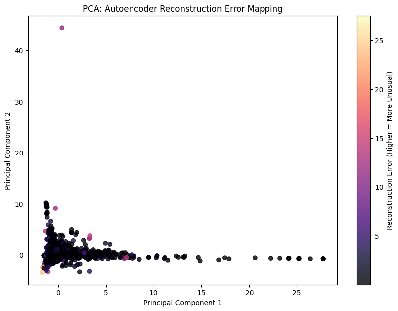

```python
from sklearn.decomposition import PCA

# 1. Reuse PCA to squash the data into 2D
pca = PCA(n_components=2)
features_2d = pca.fit_transform(scaled_features) # Use the scaled features from the AE step

# 2. Plot, using the error score to colour the points
plt.figure(figsize=(10, 7))
scatter = plt.scatter(features_2d[:, 0], features_2d[:, 1],
            c=non_spam['ae_score'],
            cmap='magma', alpha=0.8)

plt.colorbar(scatter, label='Reconstruction Error (Higher = More Unusual)')
plt.title('PCA: Autoencoder Reconstruction Error Mapping')
plt.xlabel('Principal Component 1')
plt.ylabel('Principal Component 2')
plt.show()
```

# PCA Reconstruction Error Mapping (Scatter Plot)

This plot shows where those errors actually happen in the feature space.

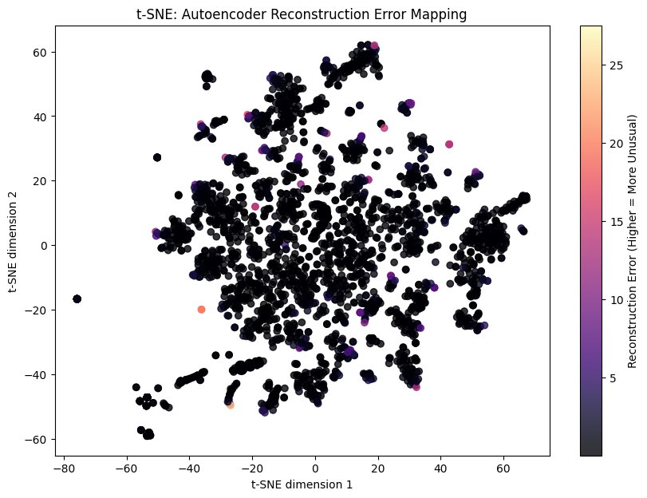

```python
from sklearn.manifold import TSNE
import matplotlib.pyplot as plt

# 1. Initialise and fit t-SNE
tsne = TSNE(n_components=2, perplexity=30, random_state=42, init='pca', learning_rate='auto')
features_tsne = tsne.fit_transform(scaled_features)

# 2. Plotting (Mirroring PCA style)
plt.figure(figsize=(10, 7))
scatter = plt.scatter(features_tsne[:, 0], features_tsne[:, 1],
            c=non_spam['ae_score'],
            cmap='magma', alpha=0.8)

plt.colorbar(scatter, label='Reconstruction Error (Higher = More Unusual)')
plt.title('t-SNE: Autoencoder Reconstruction Error Mapping')
plt.xlabel('t-SNE dimension 1')
plt.ylabel('t-SNE dimension 2')
plt.show()
```